# Analsis_Estadistico_TFM_GTZ

Ghizlane Tahiri

2024-06-19

# Librrerías necesarias

```r
#install.packages("dunn.test")
library(ggplot2)
library(gridExtra)
# install.packages("car")  # Instalar si aún no está instalado
library(car)
library(dunn.test)
#Directorio actual
getwd()
```

```
## [1] "C:/Users/34698/OneDrive/Escritorio/Trabajos_2024/TFM/Estaditicos_Dimorfismo"
```

# 1-Analisis estadístico del estudio evolutivo de genes dimórficos, específicos de micelio y de levadura.

## Obtención de los datos

```r
#cargar los datos

data_conser <- read.csv("Datos_conservacion_Lev_Mic_Dim.csv", sep=";")

print(data_conser)
```

```
##      Organismo Levadura Micelio Dim Dimorfico
## 1  Aspergillus     1949    2588 237     FALSE
## 2       Cunech     1845    2501 337      TRUE
## 3       Hesves     1875    2528 339      TRUE
## 4       Liccor     1702    2260 311      TRUE
## 5       Mucci3     2402    3206 779      TRUE
## 6       Mucend     1930    2606 461      TRUE
## 7       Mucfus     1931    2619 443      TRUE
## 8       Mucrac     1978    2669 505      TRUE
## 9        Phybl     1917     587  30     FALSE
## 10     Rhimi59     1960    2653 374     FALSE
## 11      Rhior3     1664    2122 309     FALSE
## 12       Rhipu     1895    2517 318      TRUE
## 13      Rhisto     1641    2176 319     FALSE
## 14      Sakvas     1924    2539 336     FALSE
## 15      Spoumb     1793    2357 325     FALSE
```

## Aplicación del test estadítico

Se van a comparar los organismos dimórficos frente a los no dimórficos en cuanto a composición de genes específicos de levadura, de micelio, y aquellos procedentes de clústeres dimórficos. Se va a utilizar el test de Wilcox

```r
# Realizar las pruebas de Wilcoxon
wilcox_levadura <- wilcox.test(Levadura ~ Dimorfico, data = data_conser)
wilcox_micelio <- wilcox.test(Micelio ~ Dimorfico, data = data_conser)
wilcox_dim <- wilcox.test(Dim ~ Dimorfico, data = data_conser)
```

Imprimir los resultados

```r
#
print(wilcox_levadura)
```

```
##
##  Wilcoxon rank sum exact test
##
## data:  Levadura by Dimorfico
## W = 21, p-value = 0.4634
## alternative hypothesis: true location shift is not equal to 0
```

```r
print(wilcox_micelio)
```

```
##
##  Wilcoxon rank sum exact test
##
## data:  Micelio by Dimorfico
## W = 15, p-value = 0.152
## alternative hypothesis: true location shift is not equal to 0
```

```r
print(wilcox_dim)
```

```
##
##  Wilcoxon rank sum exact test
##
## data:  Dim by Dimorfico
## W = 10, p-value = 0.04009
## alternative hypothesis: true location shift is not equal to 0
```

Sólo sale significativo al comparar los dimórficos frente a los no dimórficos en el caso de tomar en cuenta la variable de la composicón de clústeres dimórficos.

## Representación gráfica

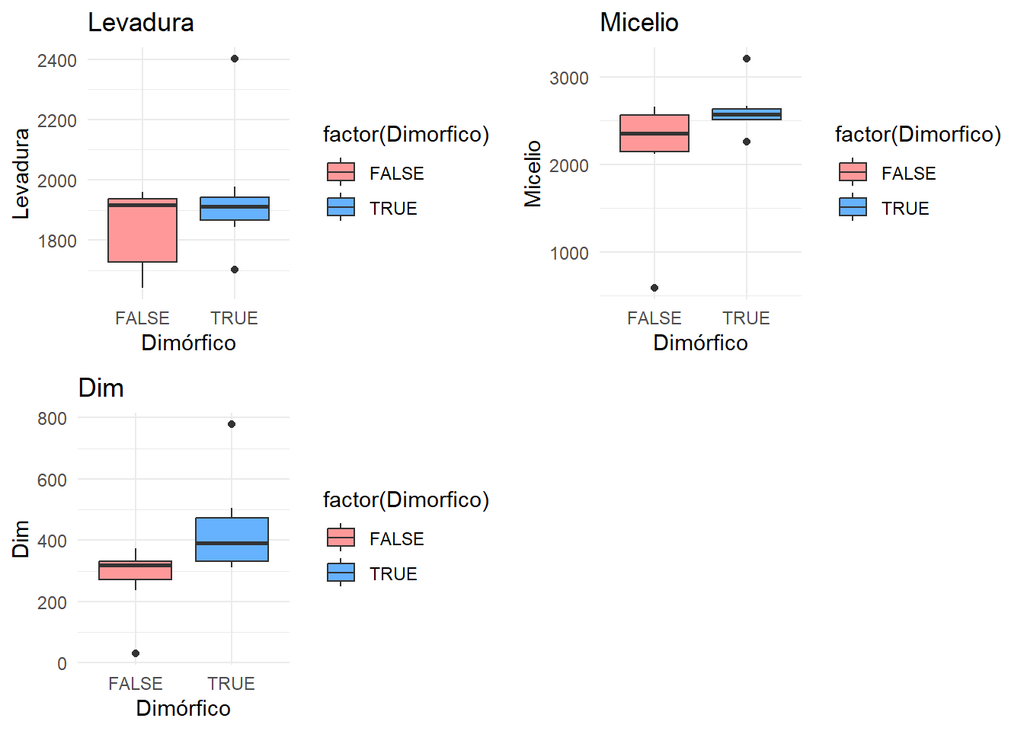

```r
# Definir una paleta de colores personalizada
color_palette <- c("#FF9999", "#66B2FF")  # Colores para FALSE y TRUE respectivamente

# Crear los gráficos de boxplot
p1_lev <- ggplot(data_conser, aes(x = as.factor(Dimorfico), y = Levadura, fill = factor(Dimorfico))) +
  geom_boxplot() +
  scale_fill_manual(values = color_palette) +
  labs(title = "Levadura", x = "Dimórfico", y = "Levadura") +
  theme_minimal()

p2_mic <- ggplot(data_conser, aes(x = as.factor(Dimorfico), y = Micelio, fill = factor(Dimorfico))) +
  geom_boxplot() +
  scale_fill_manual(values = color_palette) +
  labs(title = "Micelio", x = "Dimórfico", y = "Micelio") +
  theme_minimal()

p3_dim <- ggplot(data_conser, aes(x = as.factor(Dimorfico), y = Dim, fill = factor(Dimorfico))) +
  geom_boxplot() +
  scale_fill_manual(values = color_palette) +
  labs(title = "Dim", x = "Dimórfico", y = "Dim") +
  theme_minimal()

# Mostrar los gráficos en una cuadrícula
grid.arrange(p1_lev, p2_mic, p3_dim, ncol = 2)
```

# 2-Análisis del contenido GC de las Regiones Intergénicas de genes H2H dimórficos.

## Obtención de los datos

```r
#datos del contenido GC de los promotores bidereccionales de Levadura, Micelio y los normales o aleatorios en el genoma de Mucor lusitanicus.
data_gc_dim <- read.csv("df_gc_total.csv", sep = ";")

data_gc_dim$Tipo <- as.factor(data_gc_dim$Tipo)

#Imprimer los datos
print(data_gc_dim)
```

```
##         Tipo GC_Content
## 1    Micelio   37.73585
## 2    Micelio   40.06623
## 3    Micelio   38.01917
## 4    Micelio   39.47939
## 5    Micelio   39.23445
## 6    Micelio   35.09934
## 7    Micelio   39.11980
## 8    Micelio   39.84962
## 9    Micelio   32.33533
## 10   Micelio   42.47788
## 11   Micelio   38.70968
## 12   Micelio   33.25688
## 13  Levadura   41.66667
## 14  Levadura   40.49587
```

[output cut: 20 more lines]

## Prueba estadística del ANOVA

Como hay tres grupos, genes de micelio, de levadura y los constitutivos, se va a realizar el test ANOVA.

```r
# Realizar el ANOVA
modelo_anova <- aov(GC_Content ~ Tipo, data = data_gc_dim)

# Resumen del ANOVA
summary(modelo_anova)
```

```
##             Df Sum Sq Mean Sq F value Pr(>F)
## Tipo         2   22.5   11.26    0.83  0.445
## Residuals   31  420.5   13.56
```

### Prueba de la normalidad

Se van a analizar los residuos para comprobar las condiciones iniciales del ANOVA: la normalidad y homogeneidad de varianzas: #### Análisis mediante qqplot: No parece que los residuos sigan una distribución normal

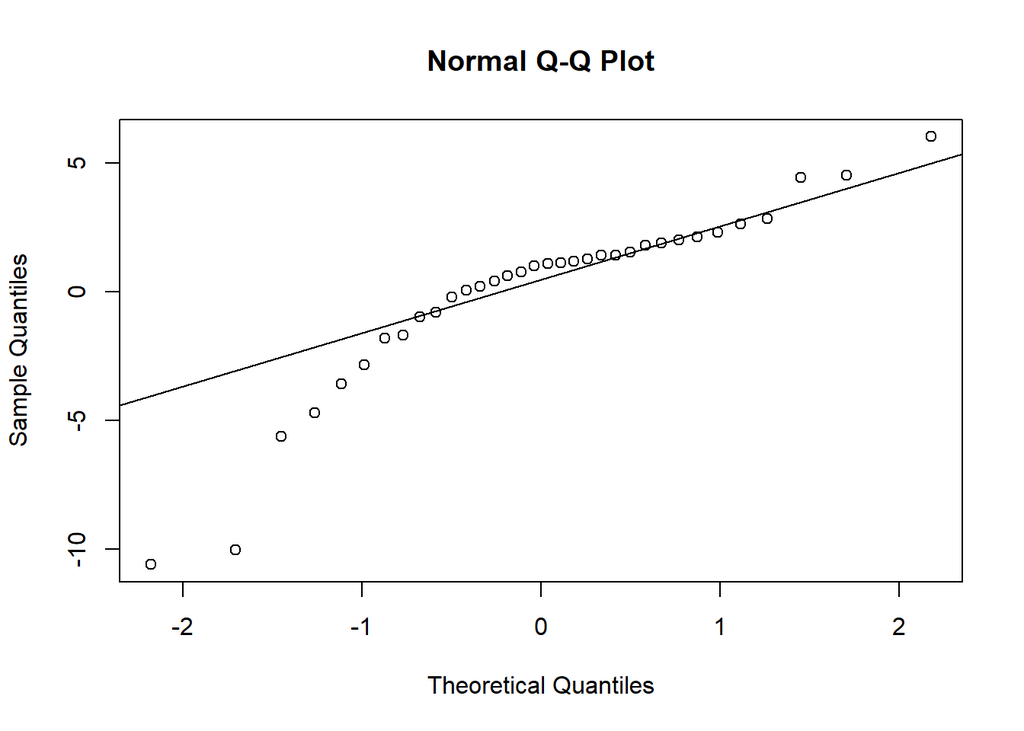

```r
#Verificacion de la normalidad de los residuos

# Obtener los residuos del modelo ANOVA
residuos <- residuals(modelo_anova)

# Gráfico QQ-plot de los residuos
qqnorm(residuos)
qqline(residuos)
```

#### Histograma de los residuos

No parece haber una distribución normal de los residuos.

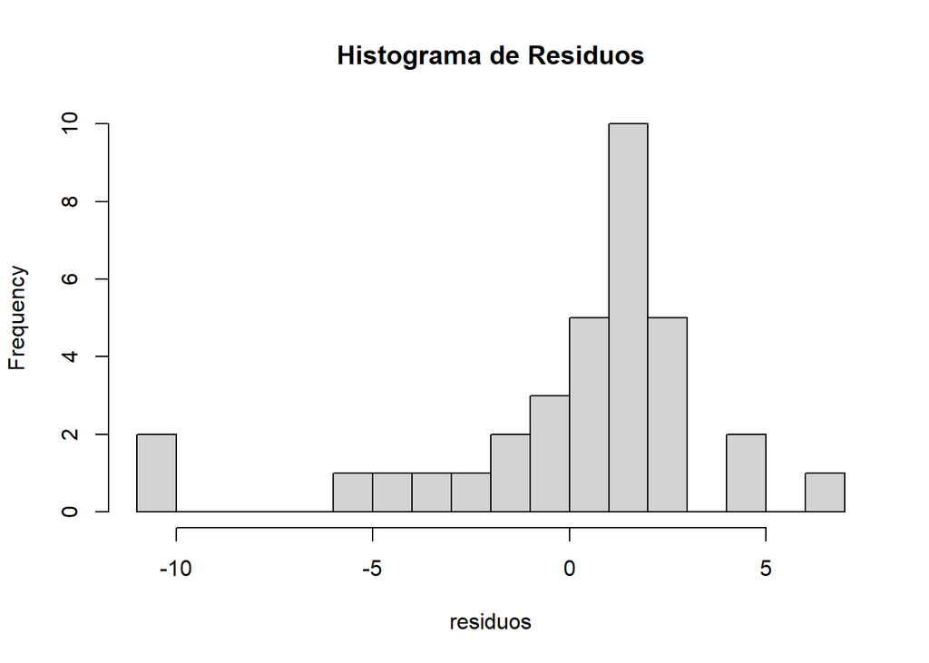

```r
# Histograma de los residuos
hist(residuos, breaks = 20, main = "Histograma de Residuos")
```

#### Prueba de Shapiro-Wilk para normalidad de los residuos El pvalor es inferior a 0.05. Se rechaza la H0 de que la muestra proviene de una pobalción normalmente distribuida.

```r
shapiro.test(residuos)
```

```
##
##  Shapiro-Wilk normality test
##
## data:  residuos
## W = 0.8669, p-value = 0.0006841
```

### Prueba de Levene para homogeneidad de varianzas

El P valor es superior a 0.05. No se rechaza de la H0.

```r
levene_test <- leveneTest(GC_Content ~ Tipo, data = data_gc_dim)
print(levene_test)
```

```
## Levene's Test for Homogeneity of Variance (center = median)
##       Df F value Pr(>F)
## group  2  0.1094 0.8967
##       31
```

```r
# P valor superior a 0.0, no se rechaza la H0, hay igualdad de varianzas.
```

No se encontraron diferencias significativas en la variabilidad de los grupos. El valor de p es 0.8967, lo que está muy por encima del umbral de significancia de 0.05. Por lo tanto, no rechaza la hipótesis nula de homogeneidad de varianzas.

## Prueba de Kruskal-Wallis

Como no se cumple la condición de la normalidad, se va a utilizar otro test para determinar si los tres grupos presentan diferencias significativas en su contenido GC:

```r
# Realizar la prueba de Kruskal-Wallis
resultado_kruskal <- kruskal.test(GC_Content ~ Tipo, data = data_gc_dim)

# Imprimir los resultados
print(resultado_kruskal)
```

```
##
##  Kruskal-Wallis rank sum test
##
## data:  GC_Content by Tipo
## Kruskal-Wallis chi-squared = 2.6155, df = 2, p-value = 0.2704
```

El p-valor es superior a 0.05. No se rechaza la H0. No hay diferencias significativas entre las medianas del contenido GC de genes de micelio, de levadura y los constitutivos.

# 3-Análisis estadístico de las diferencias en las longitudes de las Regiones Intergénicas de genes H2H dimórficos:

## Obtención de los datos

```r
#datos del contenido GC de los promotores bidereccionales de Levadura, Micelio y los normales o aleatorios en el genoma de Mucor lusitanicus.
data_len_dim <- read.csv("df_distribucion_longitudes.csv", sep = ";")
data_len_dim$Tipo <- as.factor(data_len_dim$Tipo)
#Imprimer los datos
print(head(data_len_dim))
```

```
##       Tipo longitud
## 1 Levadura      204
## 2 Levadura      242
## 3 Levadura      178
## 4 Levadura      180
## 5 Levadura      238
## 6 Levadura      430
```

## Comprobacion de la normalidad

Prueba de Shapiro-Wilk por tipo

```r
shapiro_test <- by(data_len_dim$longitud, data_len_dim$Tipo, shapiro.test)
shapiro_results <- data.frame(Tipo = names(shapiro_test), p_value = sapply(shapiro_test, "[[", "p.value"))

print(shapiro_results)
```

```
##              Tipo    p_value
## Levadura Levadura 0.02709053
## Micelio   Micelio 0.07684820
```

Dado que los datos de Levadura no siguen una distribución normal según la prueba de Shapiro-Wilk, sería más apropiado utilizar pruebas no paramétricas para comparar las longitudes entre Levadura y Micelio. Una alternativa sería la prueba de Wilcoxon-Mann-Whitney.

## Prueba de igualdad de varianzas

Prueba de Levene para igualdad de varianzas entre ‘Levadura’ y ‘Micelio’

```r
levene_test <- leveneTest(longitud ~ Tipo, data = data_len_dim)
# Imprimir los resultados
print(levene_test)
```

```
## Levene's Test for Homogeneity of Variance (center = median)
##       Df F value Pr(>F)
## group  1  0.1601 0.6933
##       20
```

En este caso, el valor p obtenido es 0.6933, lo cual indica que no hay suficiente evidencia para rechazar H0. Esto significa que no podemos concluir que las varianzas de las longitudes sean diferentes entre Levadura y Micelio.

## Prueba estadística Wilcoxon-Mann-Whitney

Realizar la prueba de Wilcoxon-Mann-Whitney (U de Mann-Whitney) para determinar si hay diferencias entre los promotores bidereccionales o regiones intergénicas de genes H2H de levadura y de micelio.

```r
wilcox_test <- wilcox.test(longitud ~ Tipo, data = data_len_dim)
# Imprimir los resultados de la prueba
print(wilcox_test)
```

```
##
##  Wilcoxon rank sum test with continuity correction
##
## data:  longitud by Tipo
## W = 52.5, p-value = 0.6443
## alternative hypothesis: true location shift is not equal to 0
```

El valor p es mayor que el nivel de significancia común de 0.05. No hay suficiente evidencia para rechazar la hipótesis nula de que las medianas de los dos grupos son iguales. No hay diferencia en la mediana de las longitudes entre los grupos Levadura y Micelio.

# 4-Analisis estádistico del contenido GC de los genes H2H de todos los hongos de este estudio.

```r
# Cargar los datos
datos_gc_otherfungi <- read.csv("df_contenidoGC_h2h_random_fungi.csv", sep = ";")
print(head(datos_gc_otherfungi))
```

```
##   Organismo GC_Content
## 1  Cunech1n   9.356725
## 2  Cunech1n  15.420561
## 3  Cunech1n  20.767494
## 4  Cunech1n   6.557377
## 5  Cunech1n  16.810345
## 6  Cunech1n  17.248460
```

```r
# Lista de pares de grupos corregida
pares <- list(
  c("Rhimi59", "Rhimi59n"),
  c("Mucci3", "Mucci3n"),
  c("Cunech1", "Cunech1n"),
  c("Hesve2finisherSC", "Hesve2finisherSCn"),
  c("Rhipu1", "Rhipu1n"),
  c("Aspnid1", "Aspnid1n"),
  c("Rhior3", "Rhior3n"),
  c("Phybl2", "Phybl2n"),
  c("Liccor1", "Liccor1n"),
  c("Sakvas1", "Sakvas1n"),
  c("Rhisto1", "Rhisto1n"),
  c("Mucfus1", "Mucfus1n"),
  c("Spoumb1", "Spoumb1n"),
  c("Mucend1", "Mucend1n"),
  c("Mucrac1", "Mucrac1n")
)
```

## Función para realizar la comparación

```r
perform_comparison <- function(organismo1, organismo2, data) {
  # Subset de los datos para los dos organismos
  grupo1 <- data$GC_Content[data$Organismo == organismo1]
  grupo2 <- data$GC_Content[data$Organismo == organismo2]

  # Imprimir mensaje de comparación
  cat("Comparación entre", organismo1, "y", organismo2, ":\n")

  # Realizar la prueba correspondiente (prueba de Shapiro-Wilk para normalidad, luego prueba t o U de Mann-Whitney)
  if (shapiro.test(grupo1)$p.value > 0.05 & shapiro.test(grupo2)$p.value > 0.05) {
    # Prueba t (suponiendo varianzas iguales)
    result <- t.test(grupo1, grupo2, var.equal = TRUE)
  } else {
    # Prueba U de Mann-Whitney (prueba no paramétrica)
    result <- wilcox.test(grupo1, grupo2)
  }

  # Imprimir el resultado de la prueba
  print(result)
  cat("\n")
}

# Loop a través de cada par en 'pares' y realizar la comparación
for (par in pares) {
  perform_comparison(par[1], par[2], datos_gc_otherfungi)
}
```

```
## Comparación entre Rhimi59 y Rhimi59n :
##
##  Wilcoxon rank sum test with continuity correction
##
## data:  grupo1 and grupo2
## W = 310788, p-value = 4.162e-06
## alternative hypothesis: true location shift is not equal to 0
##
##
## Comparación entre Mucci3 y Mucci3n :
##
##  Wilcoxon rank sum test with continuity correction
##
## data:  grupo1 and grupo2
## W = 206671, p-value = 3.473e-07
## alternative hypothesis: true location shift is not equal to 0
##
##
## Comparación entre Cunech1 y Cunech1n :
##
##  Wilcoxon rank sum test with continuity correction
##
## data:  grupo1 and grupo2
## W = 172284, p-value = 7.532e-06
## alternative hypothesis: true location shift is not equal to 0
##
##
## Comparación entre Hesve2finisherSC y Hesve2finisherSCn :
##
##  Wilcoxon rank sum test with continuity correction
##
## data:  grupo1 and grupo2
## W = 393519, p-value < 2.2e-16
## alternative hypothesis: true location shift is not equal to 0
##
##
## Comparación entre Rhipu1 y Rhipu1n :
##
##  Wilcoxon rank sum test with continuity correction
##
```

[output cut: 78 more lines]

```
##
##  Wilcoxon rank sum test with continuity correction
##
## data:  grupo1 and grupo2
## W = 91796, p-value = 0.7581
## alternative hypothesis: true location shift is not equal to 0
##
##
## Comparación entre Mucrac1 y Mucrac1n :
##
##  Wilcoxon rank sum test with continuity correction
##
## data:  grupo1 and grupo2
## W = 4038, p-value = 0.06062
## alternative hypothesis: true location shift is not equal to 0
```

# 5-Analisis estádistico de las longitudes de las regiones intergénicas de los genes H2H de todos los hongos de este estudio.

## Obtención de los datos

```r
#datos

data_len_otherfungi <- read.csv("df_longitudes_IR_fungi.csv", sep = ";")

#Imprimer los datos
print(head(data_len_otherfungi))
```

```
##          Organismo longitud
## 1 Hesve2finisherSC      465
## 2 Hesve2finisherSC      -32
## 3 Hesve2finisherSC       97
## 4 Hesve2finisherSC      -96
## 5 Hesve2finisherSC      157
## 6 Hesve2finisherSC      371
```

```r
# Asegurarse de que 'Organismo' sea un factor
data_len_otherfungi$Organismo <- as.factor(data_len_otherfungi$Organismo)
```

## Prubea estadística ANOVA

```r
# Realizar ANOVA
modelo_anova <- aov(longitud ~ Organismo, data = data_len_otherfungi)

# Resumen del ANOVA
summary(modelo_anova)
```

```
##                Df    Sum Sq Mean Sq F value Pr(>F)
## Organismo      14  19683556 1405968   68.44 <2e-16 ***
## Residuals   10633 218434804   20543
## ---
## Signif. codes:  0 '***' 0.001 '**' 0.01 '*' 0.05 '.' 0.1 ' ' 1
```

## Comproabación de condiciones para realizar el ANOVA

### Verificacion de la normalidad de los residuos

No parece haber normalidad.

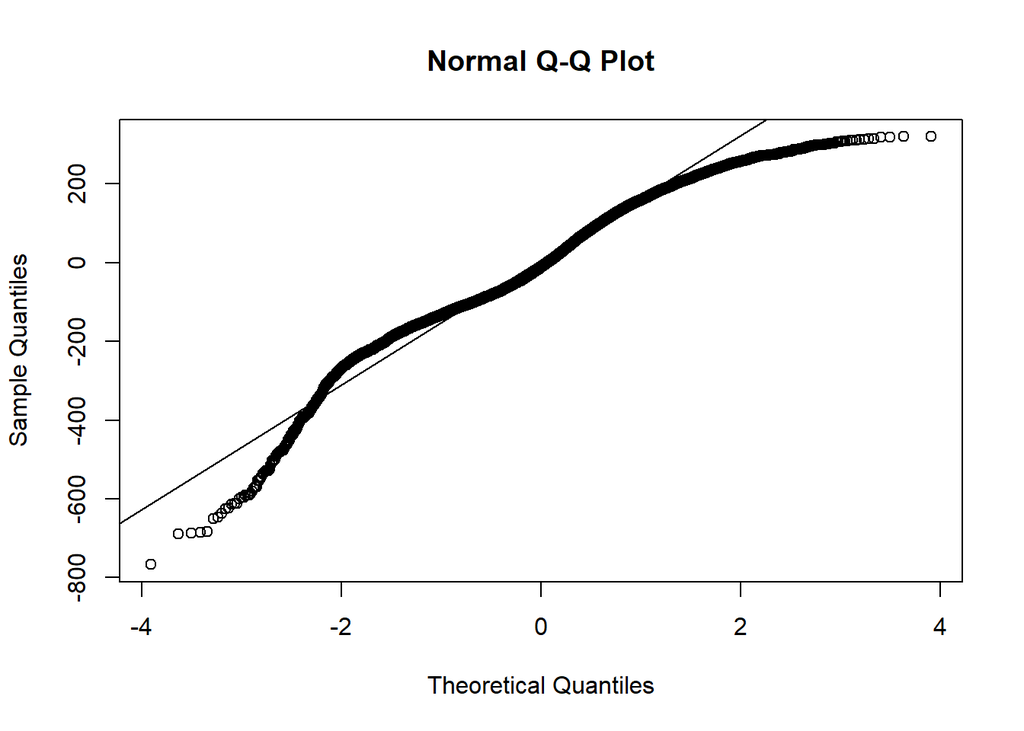

```r
# Obtener los residuos del modelo ANOVA
residuos <- residuals(modelo_anova)

# Gráfico QQ-plot de los residuos
qqnorm(residuos)
qqline(residuos)
```

#### Histograma de los residuos

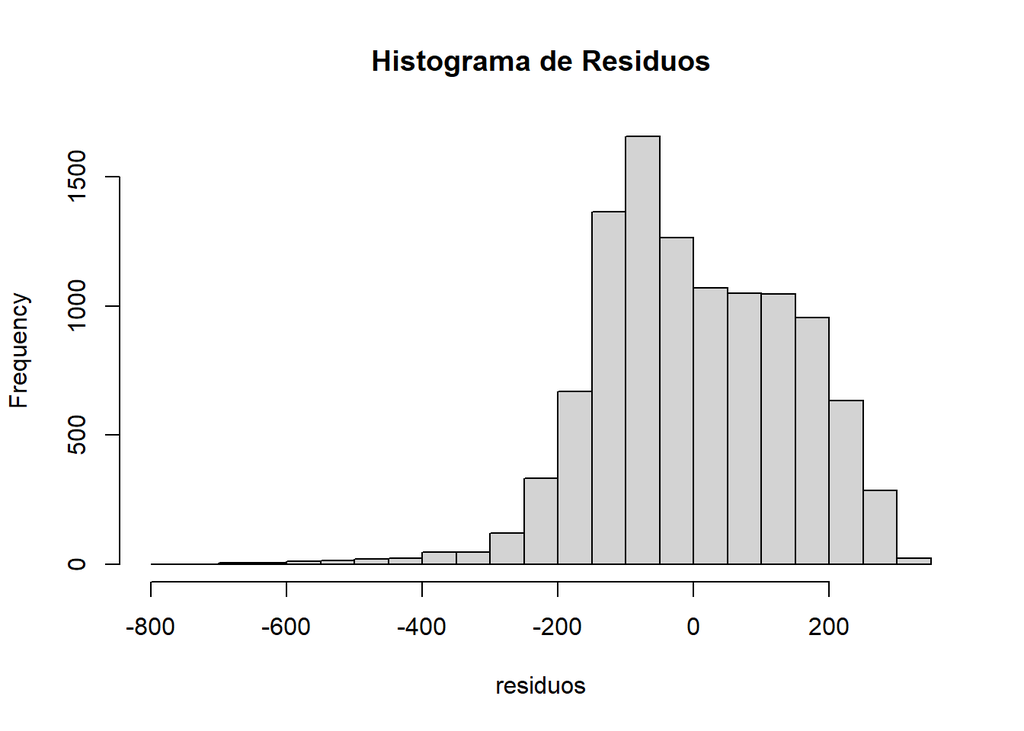

```r
hist(residuos, breaks = 20, main = "Histograma de Residuos")
```

### Verficación de la normalidad mediante la prueba de Kolmogorov-Smirnov

Dado que el tamaño de la muestra es muy grande se va a usar la prueba de Kolmogorov-Smirnov.

```r
resultado_ks <- ks.test(residuos, "pnorm", mean = mean(residuos), sd = sd(residuos))
# Imprimir los resultados
print(resultado_ks)
```

```
##
##  Asymptotic one-sample Kolmogorov-Smirnov test
##
## data:  residuos
## D = 0.045339, p-value < 2.2e-16
## alternative hypothesis: two-sided
```

Este resultado sugiere que los residuos no siguen una distribución normal.

## Homogeneidad de varianzas

Prueba de Levene para homogeneidad de varianzas.

```r
levene_test <- leveneTest(longitud ~ Organismo, data = data_len_otherfungi)
print(levene_test)
```

```
## Levene's Test for Homogeneity of Variance (center = median)
##          Df F value    Pr(>F)
## group    14  34.925 < 2.2e-16 ***
##       10633
## ---
## Signif. codes:  0 '***' 0.001 '**' 0.01 '*' 0.05 '.' 0.1 ' ' 1
```

Los datos no cumplen con las suposiciones de homogeneidad de varianzas y normalidad de los residuos para realizar un ANOVA paramétrico. ## Prueba estadística de Kruskal-Wallis

Se va a considerar utilizar una prueba no paramétrica, esto es, Prueba de Kruskal-Wallis: Para comparar medianas entre más de dos grupos.

```r
# Realizar la prueba de Kruskal-Wallis
resultado_kruskal <- kruskal.test(longitud ~ Organismo, data = data_len_otherfungi)

# Imprimir los resultados
print(resultado_kruskal)
```

```
##
##  Kruskal-Wallis rank sum test
##
## data:  longitud by Organismo
## Kruskal-Wallis chi-squared = 844.82, df = 14, p-value < 2.2e-16
```

#### Test de Dunn

Para determinar entre qué hongos hay diferencias se va a usar la prueba de Dunn.

```r
dunn_res <- dunn.test(data_len_otherfungi$longitud, g = data_len_otherfungi$Organismo, method = "bonferroni")
```

```
##   Kruskal-Wallis rank sum test
##
## data: x and group
## Kruskal-Wallis chi-squared = 844.8212, df = 14, p-value = 0
##
##
##                            Comparison of x by group
##                                  (Bonferroni)
## Col Mean-|
## Row Mean |    Aspnid1    Cunech1   Hesve2fi    Liccor1     Mucci3    Mucend1
## ---------+------------------------------------------------------------------
##  Cunech1 |   8.317778
##          |    0.0000*
## Hesve2fi |   10.56706   1.982319
##          |    0.0000*     1.0000
##  Liccor1 |   2.946601  -6.423201  -9.185794
##          |     0.1687    0.0000*    0.0000*
##   Mucci3 |   8.485648  -0.432299  -2.735441   6.592899
##          |    0.0000*     1.0000     0.3271    0.0000*
##  Mucend1 |   2.333784  -7.164744  -10.02064  -0.733484  -7.403278
##          |     1.0000    0.0000*    0.0000*     1.0000    0.0000*
##  Mucfus1 |   2.805742  -5.548075  -7.747854   0.124251  -5.568656   0.773658
##          |     0.2636    0.0000*    0.0000*     1.0000    0.0000*     1.0000
##  Mucrac1 |   0.555071  -7.358080  -9.404723  -2.204480  -7.443910  -1.615451
##          |     1.0000    0.0000*    0.0000*     1.0000    0.0000*     1.0000
##   Phybl2 |   4.863850  -4.722240  -7.583844   2.165791  -4.775771   2.954148
##          |    0.0001*    0.0001*    0.0000*     1.0000    0.0001*     0.1646
##  Rhimi59 |   14.17992   6.536407   5.347748   13.71050   7.879476   14.54948
##          |    0.0000*    0.0000*    0.0000*    0.0000*    0.0000*    0.0000*
##   Rhior3 |  -3.340016  -13.28146  -16.49505  -7.217091  -13.94284  -6.531519
##          |     0.0440    0.0000*    0.0000*    0.0000*    0.0000*    0.0000*
##   Rhipu1 |   6.378449  -2.226302  -4.442432   4.114623  -2.006630   4.843906
##          |    0.0000*     1.0000    0.0005*    0.0020*     1.0000    0.0001*
##  Rhisto1 |   11.22647   3.009409   1.264833   9.979760   3.844888   10.78907
##          |    0.0000*     0.1374     1.0000    0.0000*    0.0063*    0.0000*
##  Sakvas1 |   4.408620  -1.181958  -2.301516   2.626549  -0.978446   3.065702
##          |    0.0005*     1.0000     1.0000     0.4528     1.0000     0.1140
##  Spoumb1 |   9.415127   1.191167  -0.685284   7.739414   1.754317   8.496987
##          |    0.0000*     1.0000     1.0000    0.0000*     1.0000    0.0000*
## Col Mean-|
```

[output cut: 13 more lines]

```
##          |    0.0000*    0.0000*    0.0000*    0.0064*    0.0000*    0.0000*
##  Sakvas1 |   2.425494   3.902315   1.455584  -4.755351   7.068605   0.148536
##          |     0.8026    0.0050*     1.0000    0.0001*    0.0000*     1.0000
##  Spoumb1 |   6.675937   8.393151   6.113237  -5.363736   14.62639   3.444014
##          |    0.0000*    0.0000*    0.0000*    0.0000*    0.0000*     0.0301
## Col Mean-|
## Row Mean |    Rhisto1    Sakvas1
## ---------+----------------------
##  Sakvas1 |  -2.882528
##          |     0.2071
##  Spoumb1 |  -1.780980   1.881084
##          |     1.0000     1.0000
##
## alpha = 0.05
## Reject Ho if p <= alpha/2
```

```r
# Mostrar los resultados
print(dunn_res)
```

[output not shown]

[output cut: 108 more lines]

# 6-Análisis estadístico para determinar las diferencias entre el contenido de islas CpG de los promotores bidereccionales de genes H2H y de genes no son H2H.

## Obtención de los datos

```r
# Cargar los datos
datos_islas_otherfungi <- read.csv("islasCpG_allfungi.csv", sep = ";")
print(head(datos_islas_otherfungi))
```

```
##   Organismo CpG_Count
## 1  Cunech1n         0
## 2  Cunech1n         0
## 3  Cunech1n         0
## 4  Cunech1n         0
## 5  Cunech1n         0
## 6  Cunech1n         0
```

## Listas de organismos para hacer después las comparaciones:

```r
# Lista de organismos únicos
organismos <- unique(datos_islas_otherfungi$Organismo)

# Lista para almacenar los subconjuntos de datos
lista_datos <- list()

# Llenar la lista con subconjuntos de datos para cada organismo
for (org in organismos) {
  subset_data <- datos_islas_otherfungi$CpG_Count[datos_islas_otherfungi$Organismo == org]
  lista_datos[[org]] <- subset_data
}

# Lista de pares de grupos
pares <- list(
  c("Rhimi59", "Rhimi59n"),
  c("Mucci3", "Mucci3n"),
  c("Cunech1", "Cunech1n"),
  c("Hesve2finisherSC", "Hesve2finisherSCn"),
  c("Rhipu1", "Rhipu1n"),
  c("Aspnid1", "Aspnid1n"),
  c("Rhior3", "Rhior3n"),
  c("Phybl2", "Phybl2n"),
  c("Liccor1", "Liccor1n"),
  c("Sakvas1", "Sakvas1n"),
  c("Rhisto1", "Rhisto1n"),
  c("Mucfus1", "Mucfus1n"),
  c("Spoumb1", "Spoumb1n"),
  c("Mucend1", "Mucend1n"),
  c("Mucrac1", "Mucrac1n")
)
```

## Prueba estadística de Wilcoxon rank

Como hay casos dónde todos los datos son iguales, se va a introducir un código de errores.

```r
# Función para realizar la comparación evitando errores cuando todos los datos son idénticos
perform_comparison <- function(organismo1, organismo2, lista_datos) {
  # Obtener los datos para los dos organismos
  grupo1 <- lista_datos[[organismo1]]
  grupo2 <- lista_datos[[organismo2]]

  # Verificar si los datos extraídos son numéricos y no están vacíos
  if (any(!is.numeric(grupo1)) || any(!is.numeric(grupo2)) || length(grupo1) == 0 || length(grupo2) == 0) {
    cat("Los datos para", organismo1, "y/o", organismo2, "no son numéricos o están vacíos.\n")
    return(NULL)
  }

  # Imprimir mensaje de comparación
  cat("Comparación entre", organismo1, "y", organismo2, ":\n")

  # Verificar si todos los valores son idénticos en grupo1 o grupo2
  if (length(unique(grupo1)) == 1 | length(unique(grupo2)) == 1) {
    cat("Todos los valores en grupo1 o grupo2 son idénticos. No se puede realizar la comparación.\n")
    return(NULL)
  }

  # Realizar la prueba correspondiente (prueba t o U de Mann-Whitney)
  if (shapiro.test(grupo1)$p.value > 0.05 & shapiro.test(grupo2)$p.value > 0.05) {
    # Prueba t (suponiendo varianzas iguales)
    result <- t.test(grupo1, grupo2, var.equal = TRUE)
  } else {
    # Prueba U de Mann-Whitney (prueba no paramétrica)
    result <- wilcox.test(grupo1, grupo2)
  }

  # Imprimir el resultado de la prueba
  print(result)
  cat("\n")
}

# Realizar comparaciones para todos los pares en 'pares'
for (par in pares) {
  organismo1 <- par[1]
  organismo2 <- par[2]
  perform_comparison(organismo1, organismo2, lista_datos)
}
```

```
## Comparación entre Rhimi59 y Rhimi59n :
##
##  Wilcoxon rank sum test with continuity correction
##
## data:  grupo1 and grupo2
## W = 273969, p-value = 0.02269
## alternative hypothesis: true location shift is not equal to 0
##
##
## Comparación entre Mucci3 y Mucci3n :
##
##  Wilcoxon rank sum test with continuity correction
##
## data:  grupo1 and grupo2
## W = 263961, p-value = 4.788e-09
## alternative hypothesis: true location shift is not equal to 0
##
##
## Comparación entre Cunech1 y Cunech1n :
## Todos los valores en grupo1 o grupo2 son idénticos. No se puede realizar la comparación.
## Comparación entre Hesve2finisherSC y Hesve2finisherSCn :
##
##  Wilcoxon rank sum test with continuity correction
##
## data:  grupo1 and grupo2
## W = 360009, p-value < 2.2e-16
## alternative hypothesis: true location shift is not equal to 0
##
##
## Comparación entre Rhipu1 y Rhipu1n :
##
##  Wilcoxon rank sum test with continuity correction
##
## data:  grupo1 and grupo2
## W = 185538, p-value = 3.933e-11
## alternative hypothesis: true location shift is not equal to 0
##
##
## Comparación entre Aspnid1 y Aspnid1n :
##
```

[output cut: 45 more lines]

```
## Comparación entre Mucfus1 y Mucfus1n :
## Todos los valores en grupo1 o grupo2 son idénticos. No se puede realizar la comparación.
## Comparación entre Spoumb1 y Spoumb1n :
##
##  Wilcoxon rank sum test with continuity correction
##
## data:  grupo1 and grupo2
## W = 176323, p-value = 2.438e-06
## alternative hypothesis: true location shift is not equal to 0
##
##
## Comparación entre Mucend1 y Mucend1n :
## Todos los valores en grupo1 o grupo2 son idénticos. No se puede realizar la comparación.
## Comparación entre Mucrac1 y Mucrac1n :
## Todos los valores en grupo1 o grupo2 son idénticos. No se puede realizar la comparación.
```